# CA2

# Fourth Part:

## Analysis of Models

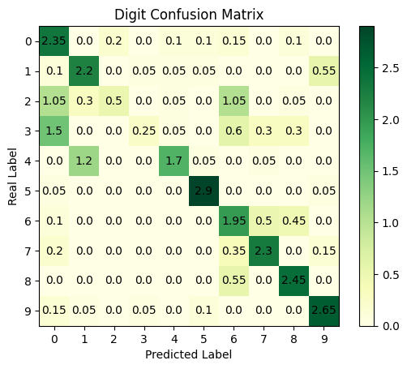

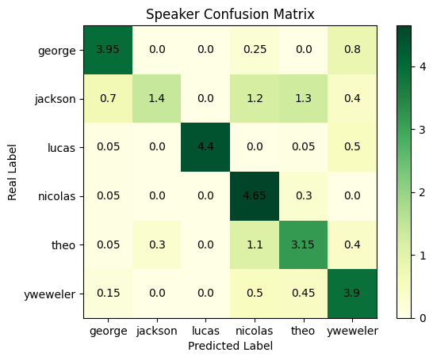

```python
digits_matrix = sk_metrics.confusion_matrix(digit_test_data_y, np.array(digits_y_predictions_scratch))/20
recorders_matrix = sk_metrics.confusion_matrix(recorder_test_data_y, np.array(recorders_y_predictions_scratch))/20

plot_confusion_matrix(digits_matrix, digit_labels, Digit)
plot_confusion_matrix(recorders_matrix, recorders_name, Speaker)
```

Then we calculate accuracy and precision.

We need to separate datas based on their target variable

```python
def data_separation(target_var, y_predictions, y_test):
    y_preds_separation = []
    y_test_separation = []

    for i in range(len(y_test)):
        if y_test[i] == target_var:
            y_test_separation.append(1)
        else:
            y_test_separation.append(0)
        if (y_predictions[i] == target_var):
            y_preds_separation.append(1)
        else:
            y_preds_separation.append(0)
    return y_test_separation, y_preds_separation
```

And we need methods to calculate metrics

```python
def calculate_accuracy_score(y_true, y_prediction, target):
    temp_y_true = []
    temp_y_pred = []
    for i in range(len(y_true)):
        temp_y_pred.append(1 if y_prediction[i] == target else 0)
        temp_y_true.append(1 if y_true[i] == target else 0)
    temp_y_true = np.array(temp_y_true)
    temp_y_pred = np.array(temp_y_pred)
    true_counter = np.sum(temp_y_true == temp_y_pred)
    total = len(y_true)
    return true_counter / total
```

```python
def calculate_precision_score(y_true, y_prediction, target):
    temp_y_true = []
    temp_y_pred = []
    for i in range(len(y_true)):
        temp_y_pred.append(1 if y_prediction[i] == target else 0)
        temp_y_true.append(1 if y_true[i] == target else 0)
    temp_y_true = np.array(temp_y_true)
    temp_y_pred = np.array(temp_y_pred)
    true_pos = np.sum((temp_y_true == 1) & (temp_y_pred == 1))
    false_pos = np.sum((temp_y_true == 0) & (temp_y_pred == 1))
    return true_pos / (true_pos + false_pos)
```

```python
def calculate_recall_score(y_true, y_prediction, target):
    temp_y_true = []
    temp_y_pred = []
    for i in range(len(y_true)):
        temp_y_pred.append(1 if y_prediction[i] == target else 0)
        temp_y_true.append(1 if y_true[i] == target else 0)
    temp_y_true = np.array(temp_y_true)
    temp_y_pred = np.array(temp_y_pred)
    true_pos = np.sum((temp_y_true == 1) & (temp_y_pred == 1))
    false_neg = np.sum((temp_y_true == 1) & (temp_y_pred == 0))
    return true_pos / (true_pos + false_neg)
```

```python
def calculate_f1_score(y_true, y_prediction, target):
    precision = calculate_precision_score(y_true, y_prediction, target)
    recall = calculate_recall_score(y_true, y_prediction, target)
    return 2 * (precision * recall) / (precision + recall)
```

```python
def accurcy_score(y, y_prediction):
    return np.sum(y == y_prediction) / len(y)
```

```python
def precision_score(y, y_prediction, classes_num, average_method="macro"):
    if average_method == average_methods[0]:
        precisions = []
        for i in range(classes_num):
            tp = np.sum((y == i) & (y_prediction == i))
            fp = np.sum((y != i) & (y_prediction == i))
            precisions.append(tp / (tp + fp) if tp + fp != 0 else 0.0)

        return np.mean(precisions)

    elif average_method == average_methods[1]:

        tp = np.sum(y == y_prediction)
        fp = np.sum(y != y_prediction)

        return tp / (tp + fp) if tp + fp != 0 else 0.0

    elif average_method == average_methods[2]:
        occurance_count = np.bincount(y)
        precisions = []
        for i in range(classes_num):

            tp = np.sum((y == i) & (y_prediction == i))
            fp = np.sum((y != i) & (y_prediction == i))

            weighted_precision = (tp / (tp + fp) if tp + fp != 0 else 0.0) * \
                (occurance_count[i] / len(y))

            precisions.append(weighted_precision)
        return np.sum(precisions)
```

```python
def recall_score(y, y_prediction, classes_num, average_method="macro"):

    recalls = []

    if average_method == average_methods[0]:
        for i in range(classes_num):
            true_pos = np.sum((y == i) & (y_prediction == i))
            false_neg = np.sum((y == i) & (y_prediction != i))
            recalls.append(true_pos / (true_pos + false_neg) if true_pos + false_neg != 0 else 0.0)
        return np.mean(recalls)

    elif average_method == average_methods[1]:

        true_pos = np.sum(y == y_prediction)
        false_neg = np.sum(y != y_prediction)
        return true_pos / (true_pos + false_neg) if true_pos + false_neg != 0 else 0.0

    elif average_method == average_methods[2]:
        occurance_count = np.bincount(y)
        for i in range(classes_num):
            true_pos = np.sum((y == i) & (y_prediction == i))
            false_neg = np.sum((y == i) & (y_prediction != i))
            weighted_recall = (true_pos / (true_pos + false_neg) if true_pos + false_neg != 0 else 0.0) * \
                (occurance_count[i] / len(y))
            recalls.append(weighted_recall)
        return np.sum(recalls)
```

```python
def f1_score(y, y_prediction, average_method="macro"):

    precision = precision_score(y, y_prediction,
                                np.max(y)+1, average_method=average_method)
    recall = recall_score(y, y_prediction,
                          np.max(y)+1, average_method=average_method)

    return 2 * (precision * recall) / (precision +
                                       recall) if precision + recall != 0 else 0.0
```

Then we calculate the metrics

```python
def calculate_metrics(y_prediction, y_test_data, target_var, target_labels):

    print(f"The {target_var} model accuracy is {sk_metrics.accuracy_score(y_test_data, np.array(y_prediction)):.2f}\n")

    for target in target_labels:
        print(f"The accuracy in {target} class is {calculate_accuracy_score(y_test_data, np.array(y_prediction), target_labels.index(target)):.2f}")
        print(f"The precision in {target} class is {calculate_precision_score(y_test_data, np.array(y_prediction), target_labels.index(target)):.2f}")
        print(f"The recall in {target} class is {calculate_recall_score(y_test_data, np.array(y_prediction), target_labels.index(target)):.2f}")
        print(f"The f1_score in {target} class is {calculate_f1_score(y_test_data, np.array(y_prediction), target_labels.index(target)):.2f}")

    for method in average_methods:
        print(f"The precision in {method} method is {precision_score(y_test_data, np.array(y_prediction), 4, average_method=method):.2f}")
        print(f"The recall in {method} method is {recall_score(y_test_data, np.array(y_prediction), 4, average_method=method):.2f}")
        print(f"The f1_score in {method} method is {f1_score(y_test_data, np.array(y_prediction),  average_method=method):.2f}")
```

### Question 1:

TP = True Positive
TN = True Negative
FP = False Positive
FN = False Negative $$\ \text{Accuracy} = \frac{\text{TP} + \text{TN}}{\text{TP} + \text{TN} + \text{FP} + \text{FN}} \$$ $$ \text{Precision} = \frac{\text{TP}}{\text{TP} + \text{FP}} $$ $$ \text{Recall} = \frac{\text{TP}}{\text{TP} + \text{FN}} $$ $$ \text{F1 score} = \frac{2 \times (\text{Precision} \times \text{Recall})}{\text{Precision} + \text{Recall}} $$

### Question 2:

Yes, it can indeed pose challenges, especially when dealing with imbalanced class distributions or when certain classes are rare compared to others. Some solutions:

- Micro-Averaging: Compute metrics globally by considering all classes together. This method can be useful when you care about overall performance across all classes equally.
- Macro-Averaging: Compute metrics independently for each class and then take the unweighted mean. This method gives equal weight to each class, which can be useful for understanding the performance of each class individually.
- Use Weighted Metrics: Use weighted versions of the metrics (weighted accuracy, weighted precision, weighted recall, weighted F1-score) to account for class imbalance. Weighted metrics give more importance to the metrics of minority classes, thus providing a more balanced evaluation.
- Use Weighted Metrics: Use weighted versions of the metrics (e.g., weighted accuracy, weighted precision, weighted recall, weighted F1-score) to account for class imbalance. Weighted metrics give more importance to the metrics of minority classes, thus providing a more balanced evaluation.
- Handling Imbalanced Data: If class imbalance is a significant issue, consider techniques such as data resampling (e.g., oversampling minority classes, undersampling majority classes) or using advanced algorithms designed to handle imbalanced datasets.
- Confusion Matrix Analysis: Analyze the confusion matrix to gain insights into the specific types of errors made by the model across different classes. This can help identify which classes are challenging to classify and where improvements are needed.

### Question 3:

`Accuracy`: Accuracy measures the overall correctness of the model predictions. it is calculated as the ratio of the number of correct predictions to the total number of data. it can be misleading when there is an imbalanced dataset.

`Percision` : Precision measures the proportion of positive predictions made by the model that are actually correct and true. it is calculated as the ratio of true positives to the sum of true positives and false positives. precision is useful when the cost of false positives is high.

`Recall` : Recall measures the proportion of actual positive instances that are correctly identified by the model. it is calculated as the ratio of true positives to the sum of true positives and false negatives . a high recall indicates that the model is good at guessing positive datas and has a low rate of false negatives.

`F1 score`: The f1 score is a harmonic mean of precision and recall providing a metric that balances both of them. it is useful when there is an imbalance between the positive and negative dataclasses.

### Question 4:

The distinction between Recall and Precision lies in their emphasis on different aspects of model performance.

Recall measures how effectively the model identifies true positive instances or relevant items. Precision indicates the ratio of correctly predicted positive instances out of all predicted positive instances. Using both Recall and Precision together is crucial because they provide complementary insights. A high value for one metric alone may not necessarily indicate a good model, depending on the specific problem and its requirements.

`High Recall Example:` Imagine a scenario where out of 1000 emails, only 10 are actually spam. If we design an algorithm that always predicts "spam," the Recall score would be 100%.

These examples illustrate how Recall and Precision capture different aspects of model performance and why it's essential to consider both metrics in context to evaluate the effectiveness of a model for a specific task.

### Question 5:

The F1 score uses the harmonic mean, which differs from the arithmetic mean. The arithmetic mean is sensitive to extreme values and is suitable for symmetrically distributed data, whereas the harmonic mean is less sensitive to extreme values and is more appropriate for skewed distributions, rates, or ratios.In the context of the F1 score, the harmonic mean helps mitigate the impact of imbalanced data distributions by providing a balanced metric that considers both precision and recall equally.

### Question 6:

```python
calculate_metrics(digit_y_predictions, digit_test_data_y, Digit, digit_labels)
```

```
The Digit model accuracy is 0.86

The accuracy in 0 class is 0.96
The precision in 0 class is 0.70
The recall in 0 class is 0.98
The f1_score in 0 class is 0.82
The accuracy in 1 class is 0.98
The precision in 1 class is 0.91
The recall in 1 class is 0.87
The f1_score in 1 class is 0.89
The accuracy in 2 class is 0.99
The precision in 2 class is 0.93
The recall in 2 class is 0.93
The f1_score in 2 class is 0.93
The accuracy in 3 class is 0.94
The precision in 3 class is 0.74
The recall in 3 class is 0.65
The f1_score in 3 class is 0.69
The accuracy in 4 class is 0.99
The precision in 4 class is 0.94
The recall in 4 class is 1.00
The f1_score in 4 class is 0.97
The accuracy in 5 class is 0.98
The precision in 5 class is 0.86
The recall in 5 class is 1.00
The f1_score in 5 class is 0.92
The accuracy in 6 class is 0.96
The precision in 6 class is 0.95
The recall in 6 class is 0.63
The f1_score in 6 class is 0.76
The accuracy in 7 class is 0.97
The precision in 7 class is 0.98
The recall in 7 class is 0.75
The f1_score in 7 class is 0.85
The accuracy in 8 class is 0.97
The precision in 8 class is 0.80
The recall in 8 class is 0.92
The f1_score in 8 class is 0.85
The accuracy in 9 class is 0.98
The precision in 9 class is 0.95
The recall in 9 class is 0.90
The f1_score in 9 class is 0.92
The precision in macro method is 0.82
The recall in macro method is 0.86
The f1_score in macro method is 0.87
The precision in micro method is 0.86
The recall in micro method is 0.86
The f1_score in micro method is 0.86
The precision in weighted method is 0.33
The recall in weighted method is 0.34
The f1_score in weighted method is 0.87
```

```python
calculate_metrics(digits_y_predictions_scratch, digit_test_data_y, Digit, digit_labels)
```

```
The Digit model accuracy is 0.64

The accuracy in 0 class is 0.87
The precision in 0 class is 0.43
The recall in 0 class is 0.78
The f1_score in 0 class is 0.55
The accuracy in 1 class is 0.92
The precision in 1 class is 0.59
The recall in 1 class is 0.73
The f1_score in 1 class is 0.65
The accuracy in 2 class is 0.91
The precision in 2 class is 0.71
The recall in 2 class is 0.17
The f1_score in 2 class is 0.27
The accuracy in 3 class is 0.91
The precision in 3 class is 0.71
The recall in 3 class is 0.08
The f1_score in 3 class is 0.15
The accuracy in 4 class is 0.95
The precision in 4 class is 0.87
The recall in 4 class is 0.57
The f1_score in 4 class is 0.69
The accuracy in 5 class is 0.99
The precision in 5 class is 0.91
The recall in 5 class is 0.97
The f1_score in 5 class is 0.94
The accuracy in 6 class is 0.88
The precision in 6 class is 0.42
The recall in 6 class is 0.65
The f1_score in 6 class is 0.51
The accuracy in 7 class is 0.95
The precision in 7 class is 0.73
The recall in 7 class is 0.77
The f1_score in 7 class is 0.75
The accuracy in 8 class is 0.95
The precision in 8 class is 0.73
The recall in 8 class is 0.82
The f1_score in 8 class is 0.77
The accuracy in 9 class is 0.96
The precision in 9 class is 0.78
The recall in 9 class is 0.88
The f1_score in 9 class is 0.83
The precision in macro method is 0.61
The recall in macro method is 0.44
The f1_score in macro method is 0.66
The precision in micro method is 0.64
The recall in micro method is 0.64
The f1_score in micro method is 0.64
The precision in weighted method is 0.24
The recall in weighted method is 0.18
The f1_score in weighted method is 0.66
```

### Question 7:

```python
calculate_metrics(recorder_y_predictions, recorder_test_data_y, Speaker, recorders_name)
```

```
The Speaker model accuracy is 0.95

The accuracy in george class is 0.99
The precision in george class is 0.98
The recall in george class is 0.99
The f1_score in george class is 0.99
The accuracy in jackson class is 0.98
The precision in jackson class is 0.95
The recall in jackson class is 0.94
The f1_score in jackson class is 0.94
The accuracy in lucas class is 0.99
The precision in lucas class is 0.99
The recall in lucas class is 0.98
The f1_score in lucas class is 0.98
The accuracy in nicolas class is 0.99
The precision in nicolas class is 0.96
The recall in nicolas class is 0.97
The f1_score in nicolas class is 0.97
The accuracy in theo class is 0.97
The precision in theo class is 0.95
The recall in theo class is 0.87
The f1_score in theo class is 0.91
The accuracy in yweweler class is 0.97
The precision in yweweler class is 0.89
The recall in yweweler class is 0.96
The f1_score in yweweler class is 0.92
The precision in macro method is 0.97
The recall in macro method is 0.97
The f1_score in macro method is 0.95
The precision in micro method is 0.95
The recall in micro method is 0.95
The f1_score in micro method is 0.95
The precision in weighted method is 0.65
The recall in weighted method is 0.65
The f1_score in weighted method is 0.95
```

```python
calculate_metrics(recorders_y_predictions_scratch, recorder_test_data_y, Speaker, recorders_name)
```

```
The Speaker model accuracy is 0.71

The accuracy in george class is 0.93
The precision in george class is 0.80
The recall in george class is 0.79
The f1_score in george class is 0.79
The accuracy in jackson class is 0.87
The precision in jackson class is 0.82
The recall in jackson class is 0.28
The f1_score in jackson class is 0.42
The accuracy in lucas class is 0.98
The precision in lucas class is 1.00
The recall in lucas class is 0.88
The f1_score in lucas class is 0.94
The accuracy in nicolas class is 0.89
The precision in nicolas class is 0.60
The recall in nicolas class is 0.93
The f1_score in nicolas class is 0.73
The accuracy in theo class is 0.87
The precision in theo class is 0.60
The recall in theo class is 0.63
The f1_score in theo class is 0.61
The accuracy in yweweler class is 0.89
The precision in yweweler class is 0.65
The recall in yweweler class is 0.78
The f1_score in yweweler class is 0.71
The precision in macro method is 0.81
The recall in macro method is 0.72
The f1_score in macro method is 0.73
The precision in micro method is 0.71
The recall in micro method is 0.71
The f1_score in micro method is 0.71
The precision in weighted method is 0.54
The recall in weighted method is 0.48
The f1_score in weighted method is 0.73
```

### Question 8:

The main distinction lies in the underlying structure of each model. One notable factor is that the hmmlearn model incorporates a convergence monitor to determine when it has reached the optimal state to terminate the program, whereas we manually set the iteration limits. Additionally, due to the efficiency limitations of our model, we cannot afford to use a higher number of iterations for better training. Another consideration is that the library model may utilize hyperparameter optimization algorithms and preprocessing techniques that we do not employ, potentially enhancing its learning capabilities.